# Logistic regression: excercises

Hicham Zmarrou

2017-12-11

### Exercise 1

Load the MASS package and combine Pima.tr and Pima.tr2 to a data.frame called train and save Pima.te as test. Change the coding of our variable of interest to (type) to 0 (non-diabetic) and 1 (diabetic). Check for and take note of any missing values.

```r
library(MASS)
library(ggplot2)
train <- rbind(Pima.tr, Pima.tr2)
test  <- Pima.te
train$type <- as.integer(train$type) - 1L
test$type <- as.integer(test$type) - 1L
# Missing values?
sapply(train, function(x) sum(is.na(x)))
```

```
npreg   glu    bp  skin   bmi   ped   age  type
    0     0    13    98     3     0     0     0
```

### Exercise 2

Take a look at the data. Plot a scatterplot matrix between all the explanatory variables using pairs(), and color code the dots according to diabetic classification. Furthermore, try to plot type as a function of age. Use jitter to make your graph more informative. Bonus: Can you add a logistic fit based on age on top of your plot?

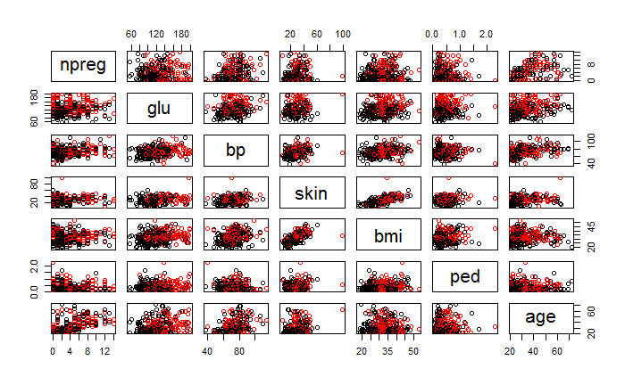

```r
library(GGally)
#ggpairs(iris, aes(colour = Species, alpha = 0.4))
pairs(subset(train, select = -c(type)), col = as.factor(train$type))
```

```r
#ggpairs(train, columns = 1:7, title = "",  colour = "type",
#  axisLabels = "show", columnLabels = colnames(train[, columns]))
```

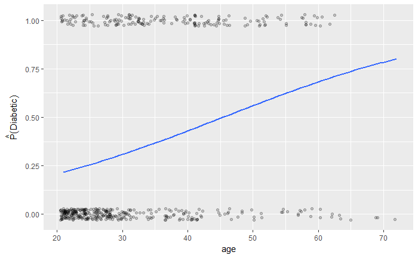

```r
library(ggplot2)
ggplot(train, aes(x = age, y = type)) +
  geom_jitter(width = 0.5, height = 0.03, alpha = .2) +
  geom_smooth(method = "glm", se = FALSE,
              method.args = list(family = "binomial")) +
  labs(y = expression(hat(P)(Diabetic)))
```

### Exercise 3

Using the glm() and the train data fit a logistic model of type on age and bmi. Print out the coefficients and their p-value.

```r
library(broom)
lg1 <- glm(type ~ age + bmi, data = train, family = binomial)
#
#summary(lg1)$coefficients[, c(1, 4)]
tidy(lg1)
```

| term | estimate | std.error | statistic | p.value |
| --- | --- | --- | --- | --- |
| (Intercept) | -5.79828987 | 0.686529780 | -8.445795 | 3.019829e-17 |
| age | 0.05383783 | 0.009043452 | 5.953239 | 2.628863e-09 |
| bmi | 0.10256607 | 0.017287117 | 5.933093 | 2.972812e-09 |

### Exercise 4

What does the model fitted in exercise 3 predict in terms of probability for someone age 35 with bmi of 32, what about bmi of 22?

```r
predict(lg1, type = "response",newdata = data.frame(bmi = c(32, 22), age = 35))
```

```
        1         2
0.3470908 0.1600962
```

```r
broom::augment(x=lg1, newdata = data.frame(bmi = c(32, 22), age = 35), type.predict = "response")
```

| bmi | age | .fitted | .se.fit |
| --- | --- | --- | --- |
| 32 | 35 | 0.3470908 | 0.02388157 |
| 22 | 35 | 0.1600962 | 0.02986424 |

Or manually define the logistic function

```r
# Or manually
lgs_fun   <- function(par, x) {
            1 / (1 + exp(-x %*% par)) # x %*% par is linear algebra equivalent of b_0 + b_1*age + b2*bmi
    }
lgs_fun(lg1$coefficients, c(1, 35, 32))
```

```
          [,1]
[1,] 0.3470908
```

```r
##           [,1]
## [1,] 0.3470908
lgs_fun(lg1$coefficients, c(1, 35, 22))
```

```
          [,1]
[1,] 0.1600962
```

### Exercise 5

According to our model what are the odds that a woman in our sample is diabetic given age 55 and a bmi 37? Remember that odds in this context have a very precise definition which is different from probability.

```r
exp(predict(lg1, response = "link", newdata = data.frame(age = 55, bmi = 37)))
```

```
       1
2.605789
```

Or literally

```r
lgs_fun(lg1$coefficients, c(1, 55, 37)) / (1 - lgs_fun(lg1$coefficients, c(1, 55, 37)))
```

```
         [,1]
[1,] 2.605789
```

```r
# or simply
exp(c(1, 55, 37) %*% lg1$coefficients)
```

```
         [,1]
[1,] 2.605789
```

### Exercise 6

Build the confusion matrix, a table of actual diabetic classification against model prediction. Use a cutoff value of 0.5, meaning that women who the model estimates to have at least 0.5 chance of being diabetic are predicted to be diabetic. What is the prediction accuracy?

```r
# Remember data is not complete ... we have missing values for bmi...
cm1 <- table(train$type[!is.na(train$bmi)], predict(lg1, type = "response") >= 0.5)
cm1
```

```
    FALSE TRUE
  0   276   48
  1   114   59
```

```r
# Prediction accuracy
sum(diag(cm1)) / sum(cm1)
```

```
[1] 0.6740443
```

```r
#
# sensitivity or recall
sensitivity(actuals = train$type[!is.na(train$bmi)], predictedScores = predict(lg1, type = "response") >= 0.5)
```

```
[1] 0.3410405
```

### Exercise 7

Apply the fitted model to the test set. Print the confusion matrix and prediction accuracy.

```r
# Check test set for missing values
sapply(test, function(x) sum(is.na(x)))
```

```
npreg   glu    bp  skin   bmi   ped   age  type
    0     0     0     0     0     0     0     0
```

```r
# Get predictions
test_pred <- predict(lg1, type = "response", newdata = test)
```

Or manually

```r
test_predm <- lgs_fun(lg1$coefficients, as.matrix(cbind(1, test[, c("age", "bmi")])))
cm1_test <- table(test$type,
                  test_pred >= 0.5)
cm1_test
```

```
    FALSE TRUE
  0   195   28
  1    67   42
```

```r
# Prediction accuracy

sum(diag(cm1_test)) / sum(cm1_test)
```

[output not shown]

```r
cm2_test = table(predicted = as.numeric(test_pred >= 0.5), actual = test$type)
library(caret)
train_con_mat = confusionMatrix(cm2_test)
c(train_con_mat$overall["Accuracy"],
  train_con_mat$byClass["Sensitivity"],
  train_con_mat$byClass["Specificity"])
```

```
   Accuracy Sensitivity Specificity
  0.7138554   0.8744395   0.3853211
```

### Exercise 8

Draw up the ROC curve and calculate the AUC.

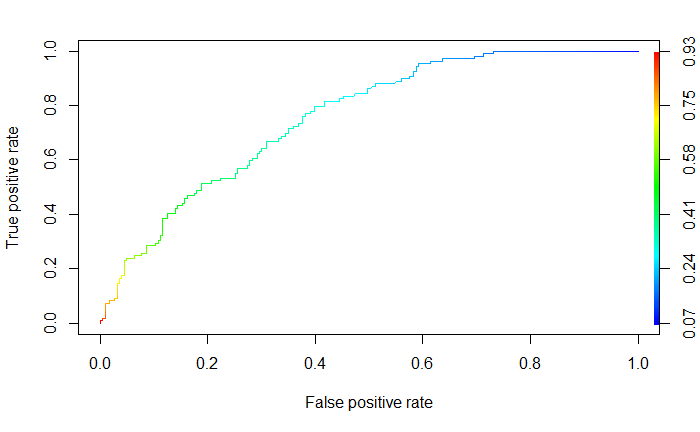

```r
library(ROCR)
# first install.packages("ROCR")
## Warning: package 'ROCR' was built under R version 3.4.2
# ROC curve
predROCR <- prediction(test_predm, test$type)
perfROCR <- performance(predROCR, "tpr", "fpr")
plot(perfROCR, colorize = TRUE)
```

```r
# Compute AUC
performance(predROCR, "auc")@y.values
```

```
[[1]]
[1] 0.7558522
```

### Exercise 9

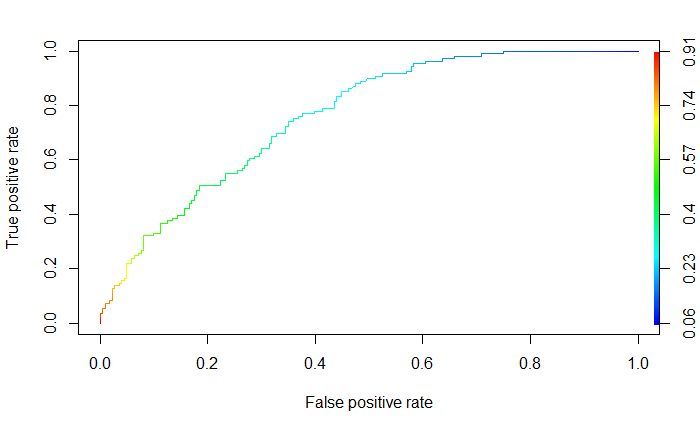

```r
lg2 <- glm(type ~ age + bmi + npreg, data = train, x = TRUE, family = binomial)
test_pred <- predict(lg2, type = "response", newdata = test)
predROCR <- prediction(test_pred, test$type)
perfROCR <- performance(predROCR, "tpr", "fpr")
plot(perfROCR, colorize = TRUE)
```

```r
performance(predROCR, "auc")@y.values
```

```
[[1]]
[1] 0.7606451
```

### Exercise 10

For a woman aged 35 and mother of 2 children, by how much does the probability of diabetes increase, if her bmi was 35 instead of 25 according to the model? What about the marginal effect at bmi = 25?

```r
ex10data <- data.frame(age = 35, bmi = c(25, 35), npreg = 2)
diff(predict(lg2, type = "response", newdata = ex10data))

diff(predict(lg2, type = "response", newdata = ex10data)) /
  predict(lg2, type = "response", newdata = ex10data)[1]
# Marginal effect at the age = 35, bmi = 25, npreg = 2

p <- lgs_fun(lg2$coefficients, c(1, 35, 25, 2))
p*(1 - p)*lg2$coefficients[3]
```

[output not shown]